# Assignment 5.2 Washington Donations

Larry Heckel

April 13, 2019

# Assignment

As an aspiring Data Scientist, you have heard that a majority of the time you can expect to spend on data acquisition and cleanup, aka data wrangling. For this assignment, you will be working with some data that has been manually entered into Donations tracking documents for Washington D.C. and Nebraska.

1. How many variables does the data set have, explain any peculiarities of the source data such as how missing values are discovered.
2. Data importing and cleaning steps are explained in the text and in the DataCamp exercises (tell me why you are doing the data cleaning activities that you perform) and follow a logical process.
3. Once your data is clean, show what the ﬁnal data set looks like. However, do not print off a data frame with 200+ rows; show me the data in the most condensed form possible.
4. Add a variable to your data set called Average Donation Amount. Calculate the Average Donation Amount per transaction and insert that value into a new data set.
5. Provide summary information using the appropriate R function(s) about the Donation Amount variable in your cleaned data set. Provide a written summary paragraph that describes your findings.

```r
# libraries to be used
library(ggplot2)
library(readr)
library(dplyr)
library(stringr)
library(psych)
# read the files individually
washDonation <- read_csv("donations-2015-2016-DC.txt")
nebrDonation <- read_csv("donations-2015-2016-NE.txt")
# View(washDonation)
# str(washDonation)
# View(nebrDonation)
# str(nebrDonation)

#Combine the two data frames into one
comboDonation <- rbind(washDonation, nebrDonation)
View(comboDonation)
str(comboDonation)
```

```
## Classes 'spec_tbl_df', 'tbl_df', 'tbl' and 'data.frame': 112191 obs. of  16 variables:
##  $ candidate_name             : chr  "DUNCAN, JEFFREY D MR" "DUNCAN, JEFFREY D MR" "AGUILAR, PETE" "AGUILAR, PETE" ...
##  $ party_affiliation          : chr  "REP" "REP" "DEM" "DEM" ...
##  $ year_of_election           : num  2016 2016 2016 2016 2016 ...
##  $ candidate_state            : chr  "SC" "SC" "CA" "CA" ...
##  $ candidate_office           : chr  "H" "H" "H" "H" ...
##  $ incumbent_challenger_status: chr  "I" "I" "I" "I" ...
##  $ committee_name             : chr  "JEFF DUNCAN FOR CONGRESS" "JEFF DUNCAN FOR CONGRESS" "PETE AGUILAR FOR CONGRESS" "PETE AGUILAR FOR CONGRESS" ...
##  $ committee_party            : chr  "REP" "REP" "DEM" "DEM" ...
##  $ donor_name                 : chr  "PAUL, JORDAN MR" "REICH, OTTO MR" "AN, EDWARD" "KADESH, MARK" ...
##  $ donor_city                 : chr  "WASHINGTON" "WASHINGTON" "WASHINGTON" "WASHINGTON" ...
##  $ donor_state                : chr  "DC" "DC" "DC" "DC" ...
##  $ donor_zip                  : num  20009 20004 20008 20002 20016 ...
##  $ donor_employer             : chr  "MOROCCAN AMERICAN CENTER FOR POLICY" "OTTO REICH ASSOCIATES, LLC" "GOOGLE" "KADESH ASSOCIATES, LLC" ...
##  $ donor_occupation           : chr  "EXECUTIVE DIRECTOR" "PRESIDENT" "PUBLIC POLICY" "CONSULTANT" ...
##  $ donation_amount            : num  2500 500 500 381 500 500 1000 2700 2700 2700 ...
##  $ donation_date              : Date, format: "2015-03-08" "2015-03-24" ...
##  - attr(*, "spec")=
##   .. cols(
##   ..   candidate_name = col_character(),
##   ..   party_affiliation = col_character(),
##   ..   year_of_election = col_double(),
##   ..   candidate_state = col_character(),
##   ..   candidate_office = col_character(),
##   ..   incumbent_challenger_status = col_character(),
##   ..   committee_name = col_character(),
##   ..   committee_party = col_character(),
##   ..   donor_name = col_character(),
##   ..   donor_city = col_character(),
##   ..   donor_state = col_character(),
##   ..   donor_zip = col_double(),
##   ..   donor_employer = col_character(),
##   ..   donor_occupation = col_character(),
##   ..   donation_amount = col_double(),
##   ..   donation_date = col_date(format = "")
##   .. )
```

## Section 1

How many variables does the data set have, explain any peculiarities of the source data such as how missing values are discovered.

The data set contains 16 variables. Each row, or observation, is the record of a donation to a candidate for a political office. In each row, there is one variable, called “donation_amount”, which records the dollar amount of the donation. The other 15 variables contain data about the donation, such as candidate and donor information.

The next step is to determine if there are missing values in any of the observations.

```r
# create data frame with rows of data that have missing values
comboNA <- comboDonation[!complete.cases(comboDonation),]
comboNA
```

```
## # A tibble: 11,552 x 16
##    candidate_name party_affiliati… year_of_election candidate_state
##    <chr>          <chr>                       <dbl> <chr>
##  1 SMITH, ADRIAN  REP                          2016 NE
##  2 KIRKPATRICK, … DEM                          2016 AZ
##  3 WYDEN, RONALD… DEM                          2016 OR
##  4 GRASSLEY, CHA… REP                          2016 IA
##  5 GRASSLEY, CHA… REP                          2016 IA
##  6 GRASSLEY, CHA… REP                          2016 IA
##  7 GRASSLEY, CHA… REP                          2016 IA
##  8 GRASSLEY, CHA… REP                          2016 IA
##  9 GRASSLEY, CHA… REP                          2016 IA
## 10 GRASSLEY, CHA… REP                          2016 IA
## # … with 11,542 more rows, and 12 more variables: candidate_office <chr>,
## #   incumbent_challenger_status <chr>, committee_name <chr>,
## #   committee_party <chr>, donor_name <chr>, donor_city <chr>,
## #   donor_state <chr>, donor_zip <dbl>, donor_employer <chr>,
## #   donor_occupation <chr>, donation_amount <dbl>, donation_date <date>
```

```r
View(comboNA)
#how many missing are in each column/variable?
colSums(is.na(comboNA))
```

```
##              candidate_name           party_affiliation
##                           0                           0
##            year_of_election             candidate_state
##                           0                           0
##            candidate_office incumbent_challenger_status
##                           0                           8
##              committee_name             committee_party
##                           0                        8222
##                  donor_name                  donor_city
##                           9                           4
##                 donor_state                   donor_zip
##                           0                          19
##              donor_employer            donor_occupation
##                        3453                        2572
##             donation_amount               donation_date
##                           0                           0
```

The two most important variables in the data set are the candidate name and the donation amount. Neither of those variables has any missing values, so we will be able to answer our most basics metrics questions, which are:

1. How many donations did each candidate receive:
2. What is the total amount of money each candidate received?
3. What is the average dollar amount of each donation, for each candidate?

Additionally, the following columns also do not have any missing values:

1. Party Affiliation
2. Year of Election
3. Candidate State
4. Candidate Office
5. Committee Name
6. Donor State
7. Donation Date

The below columns have missing values (Number missing of 112,191 total donations made).

1. Incumbent/Challenger Status (8 missing)
2. Committee Party (8,222 missing)
3. Donor Name (9 missing)
4. Donor City (4 missing)
5. Donor Zip (19 missing)
6. Donor Employer (3,453 missing)
7. Donor Occupation (2,572 missing)

## Section 2

Data importing and cleaning steps are explained in the text and in the DataCamp exercises (tell me why you are doing the data cleaning activities that you perform) and follow a logical process.

1. First, I will deal with missing metadata values. Some of the missing metatdata is not important for the analysis at hand, only that it is not empty, so for those variables, I will provide a value that will denote that it was not originally provided. For the variables that are most likely required for a good analysis, I will derive what I feel are the correct values and provide them. The details for each variable are listed below, and the code executed on the data frame below that.

   The below columns have missing values (Number missing of 112,191 total donations made).
   1. Incumbent/Challenger Status (8 missing) The two candidates for whom this value is missing only have these 8 rows, and don’t have any other entries in the data set. Therefore, we are not able to derive an appropriate value, so I will fill with “UNK” for UNKNOWN.
   2. Committee Party (8,222 missing) Is the same as Party Affiliation, so will fill with that value
   3. Donor Name (9 missing) Not an important variable, will fill with “Not Given”.
   4. Donor City (4 missing) Not an important variable, will fill with “Not Given”
   5. Donor Zip (19 missing) Not an important variable, will fill with “99999”
   6. Donor Employer (3,453 missing) Not an important variable, will fill with “Not Given”
   7. Donor Occupation (2,572 missing) Not an important variable, will fill with “Not Given”

```r
#Create new data frame called comboClean, for the clean metadata
#Start from comboDonation with the first data mutation, then each subsequent
#mutation is on comboClean.
comboClean <- comboDonation %>% mutate(donor_zip=ifelse(is.na(donor_zip), 99999, donor_zip))
comboClean <- comboClean %>% mutate(donor_name=ifelse(is.na(donor_name), "Not Given", donor_name))
comboClean <- comboClean %>% mutate(donor_city=ifelse(is.na(donor_city), "Not Given", donor_city))
comboClean <- comboClean %>% mutate(donor_employer=ifelse(is.na(donor_employer), "Not Given", donor_employer))
comboClean <- comboClean %>% mutate(donor_occupation=ifelse(is.na(donor_occupation), "Not Given", donor_occupation))
comboClean <- comboClean %>% mutate(committee_party=ifelse(is.na(committee_party), party_affiliation, committee_party))

#check for the candidates who don't have an incumber/challenger flag set
mandel <- comboDonation %>%
  filter(str_detect(candidate_name, "MANDE"))
lindbeck <- comboDonation %>%
  filter(str_detect(candidate_name, "LINDB"))
View(mandel)
View(lindbeck)

comboClean <- comboClean %>% mutate(incumbent_challenger_status=ifelse(is.na(incumbent_challenger_status), "UNK", incumbent_challenger_status))

#now check to ensure that there are no NA values
colSums(is.na(comboClean))
```

```
##              candidate_name           party_affiliation
##                           0                           0
##            year_of_election             candidate_state
##                           0                           0
##            candidate_office incumbent_challenger_status
##                           0                           0
##              committee_name             committee_party
##                           0                           0
##                  donor_name                  donor_city
##                           0                           0
##                 donor_state                   donor_zip
##                           0                           0
##              donor_employer            donor_occupation
##                           0                           0
##             donation_amount               donation_date
##                           0                           0
```

2. Now that all of the metadata is clean, we will look at the actual donation values, to see what the data distribution looks like, and if there are outliers.
   1. I will start with by checking for values less than or equal to 0 (0 or negative), because those would not make sense in terms of donations. In the context of our understanding, donations must be dollars given to a candidate, not from the candidate to the donor. We will remove those rows from the data set. There are 490 observations that meet this criteria, and are removed.

```r
donCount <- count(comboClean, vars=donation_amount <= 0)
str(donCount)
```

```
## Classes 'tbl_df', 'tbl' and 'data.frame':    2 obs. of  2 variables:
##  $ vars: logi  FALSE TRUE
##  $ n   : int  111701 490
```

```r
comboCleanDonation <- subset(comboClean,subset = (donation_amount > 0))
str(comboCleanDonation)
```

```
## Classes 'tbl_df', 'tbl' and 'data.frame':    111701 obs. of  16 variables:
##  $ candidate_name             : chr  "DUNCAN, JEFFREY D MR" "DUNCAN, JEFFREY D MR" "AGUILAR, PETE" "AGUILAR, PETE" ...
##  $ party_affiliation          : chr  "REP" "REP" "DEM" "DEM" ...
##  $ year_of_election           : num  2016 2016 2016 2016 2016 ...
##  $ candidate_state            : chr  "SC" "SC" "CA" "CA" ...
##  $ candidate_office           : chr  "H" "H" "H" "H" ...
##  $ incumbent_challenger_status: chr  "I" "I" "I" "I" ...
##  $ committee_name             : chr  "JEFF DUNCAN FOR CONGRESS" "JEFF DUNCAN FOR CONGRESS" "PETE AGUILAR FOR CONGRESS" "PETE AGUILAR FOR CONGRESS" ...
##  $ committee_party            : chr  "REP" "REP" "DEM" "DEM" ...
##  $ donor_name                 : chr  "PAUL, JORDAN MR" "REICH, OTTO MR" "AN, EDWARD" "KADESH, MARK" ...
##  $ donor_city                 : chr  "WASHINGTON" "WASHINGTON" "WASHINGTON" "WASHINGTON" ...
##  $ donor_state                : chr  "DC" "DC" "DC" "DC" ...
##  $ donor_zip                  : num  20009 20004 20008 20002 20016 ...
##  $ donor_employer             : chr  "MOROCCAN AMERICAN CENTER FOR POLICY" "OTTO REICH ASSOCIATES, LLC" "GOOGLE" "KADESH ASSOCIATES, LLC" ...
##  $ donor_occupation           : chr  "EXECUTIVE DIRECTOR" "PRESIDENT" "PUBLIC POLICY" "CONSULTANT" ...
##  $ donation_amount            : num  2500 500 500 381 500 500 1000 2700 2700 2700 ...
##  $ donation_date              : Date, format: "2015-03-08" "2015-03-24" ...
```

[output not shown]

```r
summary(comboCleanDonation$donation_amount)
```

```
##    Min. 1st Qu.  Median    Mean 3rd Qu.    Max.
##       1      25     100     399     500  244200
```

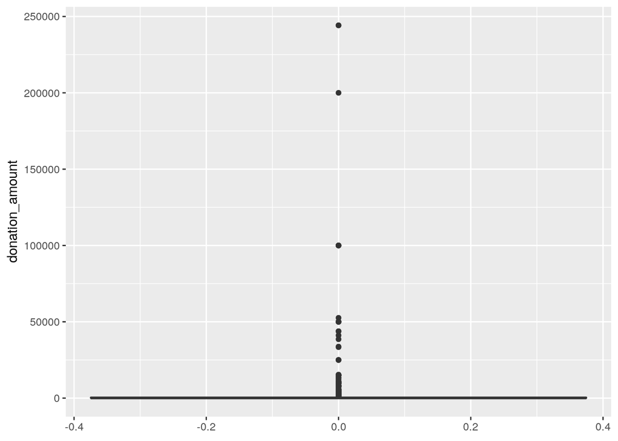

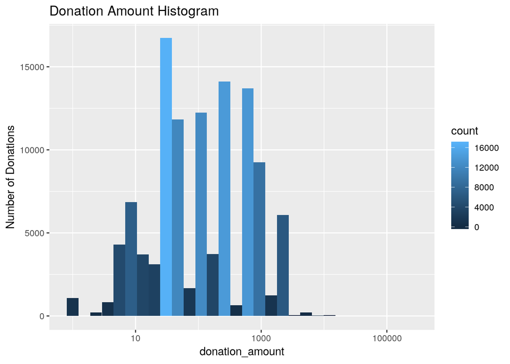

[output not shown]

[output not shown]

## Section 3

Once your data is clean, show what the ﬁnal data set looks like. However, do not print off a data frame with 200+ rows; show me the data in the most condensed form possible.

```r
str(comboCleanDonation)
```

```
## Classes 'tbl_df', 'tbl' and 'data.frame':    111701 obs. of  16 variables:
##  $ candidate_name             : chr  "DUNCAN, JEFFREY D MR" "DUNCAN, JEFFREY D MR" "AGUILAR, PETE" "AGUILAR, PETE" ...
##  $ party_affiliation          : chr  "REP" "REP" "DEM" "DEM" ...
##  $ year_of_election           : num  2016 2016 2016 2016 2016 ...
##  $ candidate_state            : chr  "SC" "SC" "CA" "CA" ...
##  $ candidate_office           : chr  "H" "H" "H" "H" ...
##  $ incumbent_challenger_status: chr  "I" "I" "I" "I" ...
##  $ committee_name             : chr  "JEFF DUNCAN FOR CONGRESS" "JEFF DUNCAN FOR CONGRESS" "PETE AGUILAR FOR CONGRESS" "PETE AGUILAR FOR CONGRESS" ...
##  $ committee_party            : chr  "REP" "REP" "DEM" "DEM" ...
##  $ donor_name                 : chr  "PAUL, JORDAN MR" "REICH, OTTO MR" "AN, EDWARD" "KADESH, MARK" ...
##  $ donor_city                 : chr  "WASHINGTON" "WASHINGTON" "WASHINGTON" "WASHINGTON" ...
##  $ donor_state                : chr  "DC" "DC" "DC" "DC" ...
##  $ donor_zip                  : num  20009 20004 20008 20002 20016 ...
##  $ donor_employer             : chr  "MOROCCAN AMERICAN CENTER FOR POLICY" "OTTO REICH ASSOCIATES, LLC" "GOOGLE" "KADESH ASSOCIATES, LLC" ...
##  $ donor_occupation           : chr  "EXECUTIVE DIRECTOR" "PRESIDENT" "PUBLIC POLICY" "CONSULTANT" ...
##  $ donation_amount            : num  2500 500 500 381 500 500 1000 2700 2700 2700 ...
##  $ donation_date              : Date, format: "2015-03-08" "2015-03-24" ...
```

## Section 4

Add a variable to your data set called Average Donation Amount. Calculate the Average Donation Amount per transaction and insert that value into a new data set.

```r
#calculate the Average Donation Amount,
#Create vector to append to data frame
AvgDonAmt <- c(mean(comboCleanDonation$donation_amount))
names(AvgDonAmt) <- c("Average Donation Amount")

#Append the Average to each row in the data frame,
#show the structure, to confirm success
comboCleanDonationAvg <- cbind(comboCleanDonation, AvgDonAmt)
str(comboCleanDonationAvg)
```

```
## 'data.frame':    111701 obs. of  17 variables:
##  $ candidate_name             : chr  "DUNCAN, JEFFREY D MR" "DUNCAN, JEFFREY D MR" "AGUILAR, PETE" "AGUILAR, PETE" ...
##  $ party_affiliation          : chr  "REP" "REP" "DEM" "DEM" ...
##  $ year_of_election           : num  2016 2016 2016 2016 2016 ...
##  $ candidate_state            : chr  "SC" "SC" "CA" "CA" ...
##  $ candidate_office           : chr  "H" "H" "H" "H" ...
##  $ incumbent_challenger_status: chr  "I" "I" "I" "I" ...
##  $ committee_name             : chr  "JEFF DUNCAN FOR CONGRESS" "JEFF DUNCAN FOR CONGRESS" "PETE AGUILAR FOR CONGRESS" "PETE AGUILAR FOR CONGRESS" ...
##  $ committee_party            : chr  "REP" "REP" "DEM" "DEM" ...
##  $ donor_name                 : chr  "PAUL, JORDAN MR" "REICH, OTTO MR" "AN, EDWARD" "KADESH, MARK" ...
##  $ donor_city                 : chr  "WASHINGTON" "WASHINGTON" "WASHINGTON" "WASHINGTON" ...
##  $ donor_state                : chr  "DC" "DC" "DC" "DC" ...
##  $ donor_zip                  : num  20009 20004 20008 20002 20016 ...
##  $ donor_employer             : chr  "MOROCCAN AMERICAN CENTER FOR POLICY" "OTTO REICH ASSOCIATES, LLC" "GOOGLE" "KADESH ASSOCIATES, LLC" ...
##  $ donor_occupation           : chr  "EXECUTIVE DIRECTOR" "PRESIDENT" "PUBLIC POLICY" "CONSULTANT" ...
##  $ donation_amount            : num  2500 500 500 381 500 500 1000 2700 2700 2700 ...
##  $ donation_date              : Date, format: "2015-03-08" "2015-03-24" ...
##  $ AvgDonAmt                  : num  399 399 399 399 399 ...
```

## Section 5

Provide summary information using the appropriate R function(s) about the Donation Amount variable in your cleaned data set. Provide a written summary paragraph that describes your findings.

```r
options(scipen=100)
options(digits=2)
summary(comboCleanDonation$donation_amount)
```

```
##    Min. 1st Qu.  Median    Mean 3rd Qu.    Max.
##       1      25     100     399     500  244200
```

```r
describe(comboCleanDonationAvg$donation_amount)
```

```
##    vars      n mean   sd median trimmed mad min    max  range skew
## X1    1 111701  399 1584    100     221 133   1 244200 244199   95
##    kurtosis  se
## X1    12936 4.7
```

### Conclusion

What all this means in real terms is that the candidates have a large number of donors who give smaller donations, and a few who give much larger donations. This is consistent with other reports of campaign contributions in other election cycles.